# Portfolio_07

John Lavack 20001249

2026-05-10

```r
knitr::opts_chunk$set(
  echo = TRUE,
  fig.width = 8,
  fig.height = 6,
  fig.align = "center"
)

library(tidyverse)
data <- read.csv("https://R-Resources.massey.ac.nz/161228/PortfolioTasks/MarineFouling2649.csv") %>%
  mutate(trial = as.factor(trial),
         richness = as.factor(richness),
         open_space = as.factor(open_space))

data %>% head(10)
```

```
##    rep trial richness open_space settlers settlers_log
## 1    8   T_1        4         50        8    2.1972246
## 2    5   T_1        8          0        1    0.6931472
## 3    3   T_1        4         50       13    2.6390573
## 4   10   T_1        1         25        3    1.3862944
## 5    6   T_1        1         50       13    2.6390573
## 6   10   T_1        4         25        7    2.0794415
## 7   10   T_1        8         25        2    1.0986123
## 8    7   T_1        4         25        7    2.0794415
## 9    7   T_1        8         25        0    0.0000000
## 10   3   T_1        1         50       12    2.5649494
```

# Fit Models

```r
model1 <- glm(settlers ~ richness + trial, family = poisson(link = 'log'), data = data)

anova(model1)
```

```
## Analysis of Deviance Table
##
## Model: poisson, link: log
##
## Response: settlers
##
## Terms added sequentially (first to last)
##
##
##          Df Deviance Resid. Df Resid. Dev  Pr(>Chi)
## NULL                        89     806.18
## richness  2   330.67        87     475.51 < 2.2e-16 ***
## trial     2   139.98        85     335.53 < 2.2e-16 ***
## ---
## Signif. codes:  0 '***' 0.001 '**' 0.01 '*' 0.05 '.' 0.1 ' ' 1
```

```r
model2 <- glm(settlers ~ open_space + trial, family = poisson(link = 'log'), data = data)

anova(model2)
```

```
## Analysis of Deviance Table
##
## Model: poisson, link: log
##
## Response: settlers
##
## Terms added sequentially (first to last)
##
##
##            Df Deviance Resid. Df Resid. Dev  Pr(>Chi)
## NULL                          89     806.18
## open_space  2   166.83        87     639.34 < 2.2e-16 ***
## trial       2   172.23        85     467.11 < 2.2e-16 ***
## ---
## Signif. codes:  0 '***' 0.001 '**' 0.01 '*' 0.05 '.' 0.1 ' ' 1
```

# Compare models

```r
qchisq(0.95, 85)
```

```
## [1] 107.5217
```

Model 1 has a residual deviance of 335.5. This is larger than the target of 107.52. We have evidence that we can do better than model 1.

```r
summary(model1)
```

```
##
## Call:
## glm(formula = settlers ~ richness + trial, family = poisson(link = "log"),
##     data = data)
##
## Coefficients:
##             Estimate Std. Error z value Pr(>|z|)
## (Intercept)  2.50330    0.08028  31.182   <2e-16 ***
## richness4   -0.94156    0.08529 -11.040   <2e-16 ***
## richness8   -1.60698    0.11466 -14.016   <2e-16 ***
## trialT_2     0.74277    0.08915   8.332   <2e-16 ***
## trialT_3    -0.20662    0.10894  -1.897   0.0579 .
## ---
## Signif. codes:  0 '***' 0.001 '**' 0.01 '*' 0.05 '.' 0.1 ' ' 1
##
## (Dispersion parameter for poisson family taken to be 1)
##
##     Null deviance: 806.18  on 89  degrees of freedom
## Residual deviance: 335.53  on 85  degrees of freedom
## AIC: 654.68
##
## Number of Fisher Scoring iterations: 5
```

Model 2 has 467.11 residual deviance. We can do better than model2. Model 1 has a lower residual deviance, therefore it is the better model of the two. Though not a complete model in any respect.

```r
summary(model2)
```

```
##
## Call:
## glm(formula = settlers ~ open_space + trial, family = poisson(link = "log"),
##     data = data)
##
## Coefficients:
##              Estimate Std. Error z value Pr(>|z|)
## (Intercept)   1.02228    0.11359   9.000  < 2e-16 ***
## open_space25  0.61238    0.11178   5.479 4.29e-08 ***
## open_space50  1.22140    0.10396  11.748  < 2e-16 ***
## trialT_2      0.92905    0.08888  10.453  < 2e-16 ***
## trialT_3     -0.05268    0.10882  -0.484    0.628
## ---
## Signif. codes:  0 '***' 0.001 '**' 0.01 '*' 0.05 '.' 0.1 ' ' 1
##
## (Dispersion parameter for poisson family taken to be 1)
##
##     Null deviance: 806.18  on 89  degrees of freedom
## Residual deviance: 467.11  on 85  degrees of freedom
## AIC: 786.27
##
## Number of Fisher Scoring iterations: 5
```

Lastly, we can compare the AIC. This will show the same outcome, that model 1 is a better model than model2 for explaining the level of settlers. $AIC = 654.68 < 786.27$

```r
AIC(model1, model2)
```

```
##        df      AIC
## model1  5 654.6828
## model2  5 786.2680
```

Note: In this situation I think it would be better to include trial as a random effect as this can impact the observations with difference between trials such as larval availability, water flow, temp and other differences between deployments of plates. However, glm() doesn’t cater to this and we haven’t covered this in lectures. Given that I don’t want to be falsely picked up for AI use, I will not use glmr() from the lme4 package. The outcome of the analysis in this portfolio won’t change. The glmr() model for richness has AIC 666, while the open_space model has AIC 799.

The models would be: model3 <- lme4::glmer(settlers ~ richness + (1 | trial), family = poisson(link = ‘log’), data = data) model4 <- lme4::glmer(settlers ~ open_space + (1 | trial), family = poisson(link = ‘log’), data = data)

# Graph

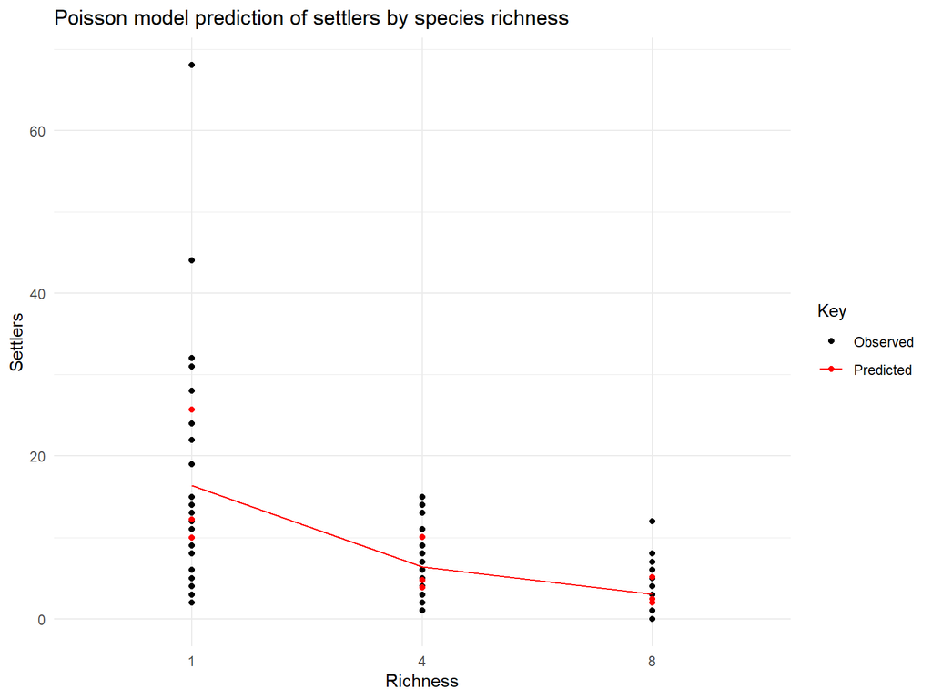

```r
data$Predicted <- model1$fitted.values

d <- data %>% group_by(richness) %>% summarise(mean = mean(Predicted))

ggplot(data = data) +
  geom_point(aes(x = richness, y = settlers, color = "Observed")) +
  geom_point(aes(x = richness, y = Predicted, color = "Predicted")) +
  geom_line(data = d, aes(x = richness, y = mean, color = "Predicted"), group = 1) +
  scale_color_manual("Key", values = c("Predicted" = "red", "Observed" = "black")) +
  labs(y = 'Settlers', x = 'Richness', title = "Poisson model prediction of settlers by species richness") +
  theme_minimal()
```

# Results

These results show that species richness is a better predictor of settlers than open space is, when using only one or the other in a simple model. As starting species richness increases on the plate, the number of settlers reduces.